# 4_Language_analysis

ZZ

2021-11-10

Application of text analyses to reveal association between stakeholders and Open Research (UNESCO) and business language. The code below includes control (book). We decided to keep only words that are unique for each of the dictionary. It will enable us see the association and the divergence across the documents. We plotted the percentage of words that documents in the stakeholders groups share with the created by us dictionaries.

RATIO = number of words from one document present in one dictionary / total number of words in the document

Note: duplicates were not removed (it matters how many times a certain word occurs in a document)

Meaning of the columns in the final dataframe: “document” - name of the document “present_BUS” - a word is present (1) or absent (0) in the business dictionary “present_UNESCO” - a word is present (1) or absent (0) in the UNESCO Recommendations “present_book” - a word is present (1) or absent (0) in the book “doc_pres” - total number of wrds present in the document (1) “sum” - a total number of words that are present in our dictionaries “stakeholder” - name of the stakeholder (funder/publisher/advocate/society/repository/journal) “proc_BUS” - % of number of words present in the certain document and business dictionary / total number of words in the certain document “proc_UNESCO” - % of number of words present in the certain document and UNESCO dictionary / total number of words in the certain document “proc_book” - % of number of words present in the certain document and book / total number of words in the certain document

```r
# Libraries used for text/data analysis
library(tidyverse)
```

```r
library(dplyr)
library(tidytext)

# Libraries used to create plots
library(ggplot2)

# Library to create a table when converting to html
library("kableExtra")
```

# Importing data

```r
# Data: words, stakeholder, documents...
df_corpuses <- read_csv("./output/created_datasets/cleaned_data.csv")
data_words <- df_corpuses

# Dictionary data
all_dict <- read_csv("./output/created_datasets/freq_dict_total_100.csv")
```

# Removing duplicates

```r
dictionaries <- all_dict %>%
  select(dictionary, word) %>%
  mutate(present_in_dict = 1)

bus_dict <- dictionaries %>%
  filter(dictionary == "business_language") %>%
  rename(present_BUS = present_in_dict)

unesco_dict <- dictionaries %>%
  filter(dictionary == "UNESCO") %>%
  rename(present_UNESCO = present_in_dict)

book_dict <- dictionaries %>%
  filter(dictionary == "book") %>%
  rename(present_book = present_in_dict)

dictionaries_added <- dictionaries %>%
  left_join(bus_dict, by = c("word" = "word"))  %>%
  left_join(unesco_dict, by = c("word" = "word"))  %>%
  left_join(book_dict, by = c("word" = "word")) %>%
  select(present_in_dict, word, present_BUS, present_UNESCO, present_book) %>%
   replace(is.na(.), 0) %>%
  distinct(word, .keep_all = TRUE) %>% # removing duplicates
  mutate(present_BUS = as.numeric(present_BUS)) %>%
  mutate(present_UNESCO = as.numeric(present_UNESCO)) %>%
  mutate(present_book = as.numeric(present_book))  %>%
  mutate(sum = rowSums(.[3:5]))

##############################################

# For my analysis choosing unique words from the dictionaries
dictionaries_added <- dictionaries_added %>%
  filter(sum == 1)

dictionaries <- dictionaries_added


# Number of words per dictionary after removing duplicates (leaving only words unique for each of the dictionary)

book_words_no <- dictionaries_added %>%
  filter(present_book == 1) %>%
  count()

print(paste("Number of words in the control (book) dictionary after removing duplicates:", book_words_no))
```

```
[1] "Number of words in the control (book) dictionary after removing duplicates: 85"
```

```r
unesco_words_no <- dictionaries_added %>%
  filter(present_UNESCO == 1) %>%
  count()

print(paste("Number of words in UNESCO dictionary after removing duplicates:", unesco_words_no))
```

```
[1] "Number of words in UNESCO dictionary after removing duplicates: 84"
```

```r
business_words_no <- dictionaries_added %>%
  filter(present_BUS == 1) %>%
  count()

print(paste("Number of words in business dictionary after removing duplicates:", business_words_no))
```

```
[1] "Number of words in business dictionary after removing duplicates: 82"
```

```r
# Data preparation

# Changing name of the dictionary variable
new_dictionary <- dictionaries
## Getting a data set with the words
data_words <- df_corpuses

# Merging and removing duplicates
data_words <- data_words %>%
  rename(document = name) %>%
  select(document, stakeholder, word) %>%
  left_join(new_dictionary, by = c("word" = "word")) # merging

# Adding a column with stakeholder and word together to allow merging later
data_words$stake_word <- paste(data_words$stakeholder, "_", data_words$word)
# Adding a column with a document name and word together to allow merging later
data_words$doc_word <- paste(data_words$document, "_", data_words$word)
# Adding a column that will be used later to calculate the total of unique words in the document (dictionaries without removed words)
data_words$doc_pres <- 1

# Adding two columns that will be used later to calculate the total of unique words in the document (new dictionaries with removed common words)

# Replace NAs with 0 in all absence/presence columns
data_words_ND <- data_words %>%
  mutate_at(vars(present_BUS, present_UNESCO, present_book, sum), ~replace_na(., 0)) # replacing NAs


## Preparing columns used to creating ternary plots
# Select columns of my interest (stakeholders) and aggregate

data_words_ND <- data_words_ND %>%
  select(document, stakeholder, word, present_BUS, present_UNESCO, present_book, doc_pres, sum) # selecting columns, sum - column with the information about in how many dictionaries a certain word occurs

df_sum_pres_ND <- aggregate(x = data_words_ND[,4:8], by = list(data_words_ND$document), FUN = sum, na.rm = TRUE)


# By doing aggregate I lost info about the stakeholder the doc come from, I want to add it
df_doc_ord <- data_words_ND %>%
  select(document, stakeholder) %>%
  distinct(document, .keep_all = TRUE)

df_sum_pres_ND <- df_sum_pres_ND %>%
  left_join(df_doc_ord, by = c("Group.1" = "document")) %>%
  rename(document = Group.1)

# Creating % columns in a new df_sum_proc_ND data frame
df_sum_proc_ND <- df_sum_pres_ND

df_sum_proc_ND$proc_BUS <-df_sum_proc_ND$present_BUS/df_sum_proc_ND$doc_pres*100
df_sum_proc_ND$proc_UNESCO <- df_sum_proc_ND$present_UNESCO/df_sum_proc_ND$doc_pres*100
df_sum_proc_ND$proc_book <- df_sum_proc_ND$present_book/df_sum_proc_ND$doc_pres*100


# Additional information about the data
# Stakeholders (2 from each of the stakeholders) that shared the highest no of words with UNESCO recommendation

UNESCO_stak_top <- df_sum_proc_ND %>%
  group_by(stakeholder) %>%
  arrange(desc(proc_UNESCO)) %>%
  slice_head(n=2) %>%
  select(stakeholder, document, proc_UNESCO)

UNESCO_stak_top %>%
  kbl(caption = "Stakeholders that shared the higest no of words with UNESCO recommendation:") %>%
  kable_classic("hover", full_width = T)
```

Stakeholders that shared the higest no of words with UNESCO recommendation:

| stakeholder | document | proc_UNESCO |
| --- | --- | --- |
| advocates | Jisc | 42.85714 |
| advocates | ROpenSci | 40.74074 |
| funders | JST | 43.82022 |
| funders | NRF South Africa | 43.56436 |
| journals | Conservation Letters | 23.52941 |
| journals | Remote Sensing in Ecology and Conservation | 23.30097 |
| publishers | AIBS | 29.78723 |
| publishers | eLife | 29.76190 |
| repositories | Dryad | 32.59259 |
| repositories | Harvard Dataverse | 31.50685 |
| societies | The Royal Society | 37.20930 |
| societies | Ecological Society of Australia | 32.23141 |

```r
# Stakeholders (2 from each of the stakeholders) that shared the highest no of words with business dictionary

business_stak_top <- df_sum_proc_ND %>%
  group_by(stakeholder) %>%
  arrange(desc(proc_BUS)) %>%
  slice_head(n=2) %>%
  select(stakeholder, document, proc_BUS)

business_stak_top %>%
  kbl(caption = "Stakeholders that shared the higest no of words with business dictionary:") %>%
  kable_classic("hover", full_width = T)
```

Stakeholders that shared the higest no of words with business dictionary:

| stakeholder | document | proc_BUS |
| --- | --- | --- |
| advocates | Amelica | 8.000000 |
| advocates | Gitlab | 6.000000 |
| funders | Consortium of African Funds for the Environment | 11.304348 |
| funders | CONICYT | 5.660377 |
| journals | Journal of Applied Ecology | 7.228916 |
| journals | Biological Conservation | 5.521472 |
| publishers | PeerJ | 7.017544 |
| publishers | BioOne | 5.970149 |
| repositories | Australian Antarctic Data Centre | 10.377358 |
| repositories | bioRxiv | 4.494382 |
| societies | National Academy of Sciences | 4.629630 |
| societies | SORTEE | 3.571429 |

```r
# Stakeholders (2 from each of the stakeholders) that shared the highest no of words with book dictionary (control)

book_stak_top <-  df_sum_proc_ND %>%
  group_by(stakeholder) %>%
  arrange(desc(proc_book)) %>%
  slice_head(n=2) %>%
  select(stakeholder, document, proc_book)

book_stak_top %>%
  kbl(caption = "Stakeholders that shared the higest no of words with book dictionary (control):") %>%
  kable_classic("hover", full_width = T)
```

Stakeholders that shared the higest no of words with book dictionary (control):

| stakeholder | document | proc_book |
| --- | --- | --- |
| advocates | Reference Center for Environmental Information | 7.500000 |
| advocates | Coko | 7.291667 |
| funders | Sea World Research and Rescue Foundation | 9.243697 |
| funders | Chinese Academy of Sciences | 8.823529 |
| journals | Conservation Biology | 10.891089 |
| journals | Diversity and Distributions | 5.607477 |
| publishers | The Royal Society Publishing | 8.333333 |
| publishers | The University of Chicago Press | 6.832298 |
| repositories | GBIF | 8.333333 |
| repositories | EcoEvoRxiv | 6.000000 |
| societies | The Zoological Society of London | 10.439560 |
| societies | British Ecological Society | 6.000000 |

# Graphs

```r
no <- nrow(df_sum_proc_ND)
no
```

```
[1] 129
```

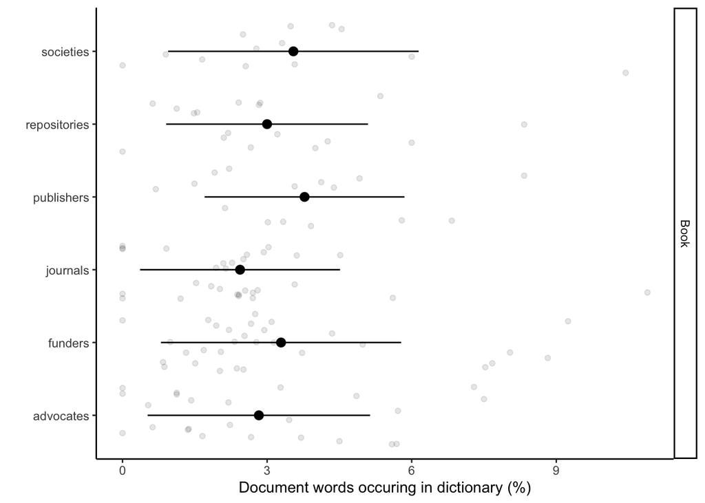

```r
# Plotting them separately book
df_sum_proc_ND_book = data.frame(
  document = rep(df_sum_proc_ND$document,1),
  stakeholder = rep(df_sum_proc_ND$stakeholder,1),
  type = c(rep("Book",no)),
  perc = c(df_sum_proc_ND$proc_book),
  perc2 = c(df_sum_proc_ND$proc_book))

sum_df_sum_proc_ND_book =
  df_sum_proc_ND_book %>%
  group_by(stakeholder, type) %>%
  dplyr::summarise(perc = mean(perc), SD = sd(perc2))
fig_book <- ggplot() +
  geom_point(data = df_sum_proc_ND_book, aes(x = perc, y = stakeholder), alpha = 0.1, position = position_jitter()) +
  geom_pointrange(data = sum_df_sum_proc_ND_book, aes(x = perc, xmin = perc - SD, xmax = perc + SD, y = stakeholder)) +
  facet_grid(type~.) +
  labs(x = "Document words occuring in dictionary (%)", y = "") +
  scale_colour_discrete(guide = F) +
  theme_classic()
fig_book
```

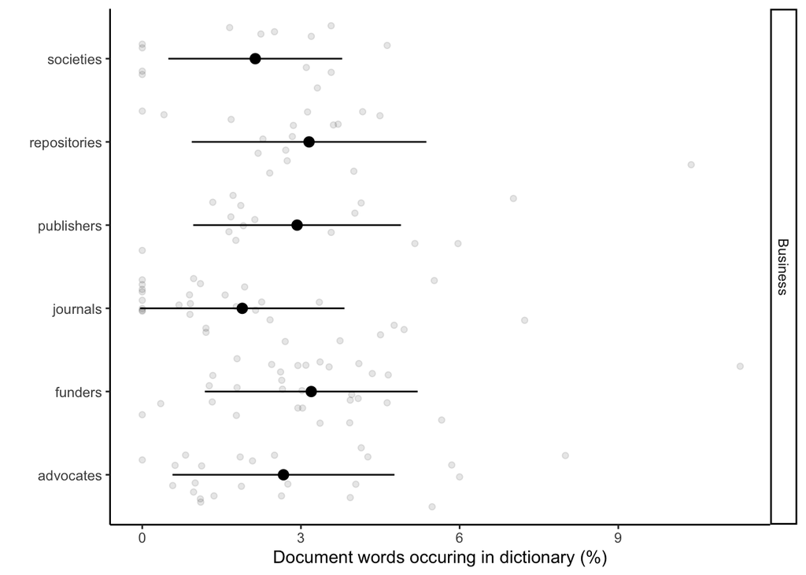

```r
# Saving the figure
figure_name <- paste0("./output/Other_figures/language_book.png")
ggsave(filename = figure_name, fig_book + theme_bw(base_size = 5),
     width = 10, height = 5, dpi = 600, units = "in", device='png')
# Plotting them separately Business
df_sum_proc_ND_BUS = data.frame(
  document = rep(df_sum_proc_ND$document,1),
  stakeholder = rep(df_sum_proc_ND$stakeholder,1),
  type = c(rep("Business",no)),
  perc = c(df_sum_proc_ND$proc_BUS),
  perc2 = c(df_sum_proc_ND$proc_BUS))

sum_df_sum_proc_ND_BUS =
  df_sum_proc_ND_BUS %>%
  group_by(stakeholder, type) %>%
  dplyr::summarise(perc = mean(perc), SD = sd(perc2))
fig_bus <- ggplot() +
  geom_point(data = df_sum_proc_ND_BUS, aes(x = perc, y = stakeholder), alpha = 0.1, position = position_jitter()) +
  geom_pointrange(data = sum_df_sum_proc_ND_BUS, aes(x = perc, xmin = perc - SD, xmax = perc + SD, y = stakeholder)) +
  facet_grid(type~.) +
  labs(x = "Document words occuring in dictionary (%)", y = "") +
  scale_colour_discrete(guide = F) +
  theme_classic()

fig_bus
```

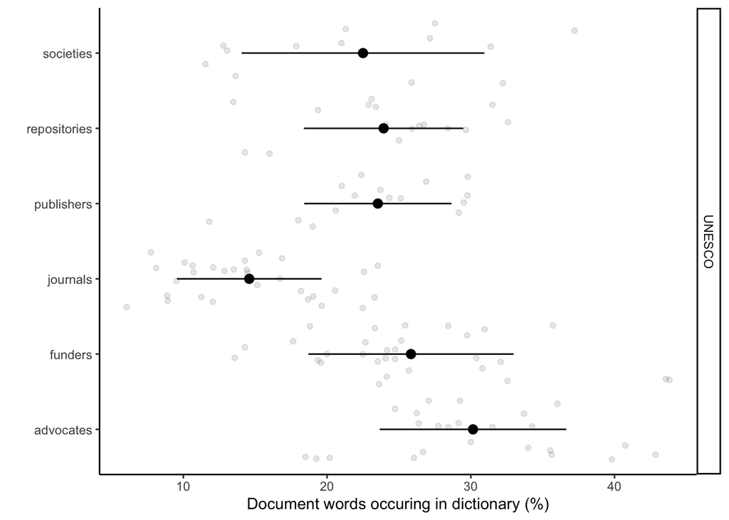

```r
# Saving the figure
figure_name <- paste0("./output/Figure_2C/language_business.png")
ggsave(filename = figure_name, fig_bus + theme_bw(base_size = 5),
     width = 10, height = 5, dpi = 600, units = "in", device='png')
# Plotting them separately UNESCO
df_sum_proc_ND_UNESCO = data.frame(
  document = rep(df_sum_proc_ND$document,1),
  stakeholder = rep(df_sum_proc_ND$stakeholder,1),
  type = c(rep("UNESCO",no)),
  perc = c(df_sum_proc_ND$proc_UNESCO),
  perc2 = c(df_sum_proc_ND$proc_UNESCO))

sum_df_sum_proc_ND_UNESCO =
  df_sum_proc_ND_UNESCO %>%
  group_by(stakeholder, type) %>%
  dplyr::summarise(perc = mean(perc), SD = sd(perc2))
fig_unesco <- ggplot() +
  geom_point(data = df_sum_proc_ND_UNESCO, aes(x = perc, y = stakeholder), alpha = 0.1, position = position_jitter()) +
  geom_pointrange(data = sum_df_sum_proc_ND_UNESCO, aes(x = perc, xmin = perc - SD, xmax = perc + SD, y = stakeholder)) +
  facet_grid(type~.) +
  labs(x = "Document words occuring in dictionary (%)", y = "") +
  scale_colour_discrete(guide = F) +
  theme_classic()
fig_unesco
```

```r
# Saving the figure
figure_name <- paste0("./output/Figure_2C/language_unesco.png")
ggsave(filename = figure_name, fig_unesco  + theme_bw(base_size = 5),
     width = 10, height = 5, dpi = 600, units = "in", device='png')
```